# Progetto Data Science

2024-12-04

# Analisi dei Dati Airbnb in Sicilia: Un Caso Studio

## Introduzione

Airbnb nasce nel 2008 dall’idea di due designer che decisero di affittare il proprio spazio in più a tre viaggiatori in cerca di un alloggio. Lo scopo del progetto è analizzare in ottica data-driven le peculiarità e le correlazioni tra le variabili del dataset ,inoltre si concentra sulla differenza tra il dataset intero ed un sottoinsieme (COASTAL) dove si vanno ad evidenziare quali e se ci sono differenze tra questi due insiemi geograficamente ed economicamente differenti. Il dataset in questione si trova sul sito kaggle pubblicato da [Alessio Crisafulli](https://www.kaggle.com/datasets/alessiocrisafulli/airbnb-italy).

La Sicilia rappresenta un caso studio ideale per il forte interesse turistico, la varietà di paesaggi e la concentrazione di località costiere che si prestano a un confronto dettagliato tra aree costiere e non. Il dataset si presenta in maniera pulita, senza necessità di interventi significativi.

Per dividere i dati in alloggi costieri e non, ho inizialmente utilizzato un modello di intelligenza artificiale, ma a causa delle limitazioni delle API di OpenAI, ho optato per una scissione manuale. L’approccio manuale consente di includere solo i comuni effettivamente riconosciuti come località costiere, evitando discrepanze derivanti da confini geografici imprecisi. Qui sotto lascio il codice per eventuali miglioramenti futuri.

```r
my_API <- "******"#qui andra inserita la key personale


# adesso si crea una funzione che ci permette di interfacciarsi con la macchina tramite protocollo http
hey_chatGPT <- function(question) {
  system_message <- Sys.getenv("SYSTEM_MESSAGE")

  response <- POST(
    url = "https://api.openai.com/v1/chat/completions",
    add_headers(Authorization = paste("Bearer", my_API)),
    content_type_json(),
    encode = "json",
    body = toJSON(list(
      model = "gpt-3.5-turbo",
      messages = list(
        list(
          role = "system",
          content = system_message
        ),
        list(
          role = "user",
          content = question
        )
      )
    ),auto_unbox = TRUE)
  )


  return(response_content$choices[[1]]$message$content)
}
#nella variabile "query" andiamo a scrivere la nostra frase da comunicare a chatgpt e dopo richiamiamo la funzione dichiarata precedentemente
query <- "Forniscimi i comuni costieri della Sicilia"
##response <- hey_chatGPT(query)

##print(response)
```

Il problema tecnico è stato riuscire a rendere interpretabile la risposta dalle funzioni presenti in R, quindi ho avuto bisogno di standardizzare il più possibile la risposta evitando caratteri inutili o imprevedibili.

Il modello è in grado di essere addestrato e di impostare alcuni presets ,tuttavia la comunicazione tramite API bypassa tali impostazioni rendendo impossibile ricevere risposte standardizzate.

### Nota Metodologica

Questa analisi si è avvalsa di dati fittizi per quanto riguarda la componente temporale. Poiché il dataset originale non conteneva informazioni dettagliate sulla variazione dei prezzi e delle prenotazioni nel corso del tempo, sono stati introdotti dati simulati per modellare fenomeni come la stagionalità e le fluttuazioni estive nelle aree costiere. Questo approccio ha consentito di esplorare dinamiche ipotetiche e di ampliare le possibilità di interpretazione, pur mantenendo la consapevolezza dei limiti derivanti dall’assenza di dati reali su questo aspetto.

### Importazione dei Dati

Passiamo adesso al dataset vero e proprio ed incominciamo con il caricamento:

### Data Cleaning

Il secondo passo è quello di rendere il dataset utilizzabile per le nostre analisi e snellirlo per facilitarne la lettura

```r
data_sicilia$price <- as.numeric(gsub("\\$", "", data_sicilia$price))# rendo numerica una variabile char

data_sicilia$host_is_superhost <- ifelse(data_sicilia$host_is_superhost=="", "si", data_sicilia$host_is_superhost)#cambio nome a dei char ed assegno i mancanti
data_sicilia$host_is_superhost <- ifelse(data_sicilia$host_is_superhost=="t", "si", data_sicilia$host_is_superhost)
data_sicilia$host_is_superhost <- ifelse(data_sicilia$host_is_superhost=="f", "no", data_sicilia$host_is_superhost)
data_sicilia$instant_bookable <- ifelse(data_sicilia$instant_bookable=="t","Si",data_sicilia$instant_bookable)
data_sicilia$instant_bookable <- ifelse(data_sicilia$instant_bookable=="f","No",data_sicilia$instant_bookable)

data_sicilia$host_has_profile_pic = ifelse(data_sicilia$host_has_profile_pic == "t", "si",data_sicilia$host_has_profile_pic)
data_sicilia$host_has_profile_pic = ifelse(data_sicilia$host_has_profile_pic == "f", "no",data_sicilia$host_has_profile_pic)

data_sicilia$host_identity_verified = ifelse(data_sicilia$host_identity_verified == "t", "si", data_sicilia$host_identity_verified)
data_sicilia$host_identity_verified = ifelse(data_sicilia$host_identity_verified == "f", "no", data_sicilia$host_identity_verified)

data_sicilia <- data_sicilia %>%
  select(id,host_is_superhost,neighbourhood,neighbourhood_cleansed,latitude,longitude,room_type,accommodates,bedrooms,amenities,price,number_of_reviews,review_scores_rating,review_scores_value,minimum_nights_avg_ntm,host_response_time,instant_bookable,beds,host_has_profile_pic,host_identity_verified) #snellisco il dataset per renderlo più facilmente interpretabile
```

### Visualizzazione della Mappa di Base

Utilizziamo ggplot2 per visualizzare una mappa della Sicilia basata sul file GeoJSON:

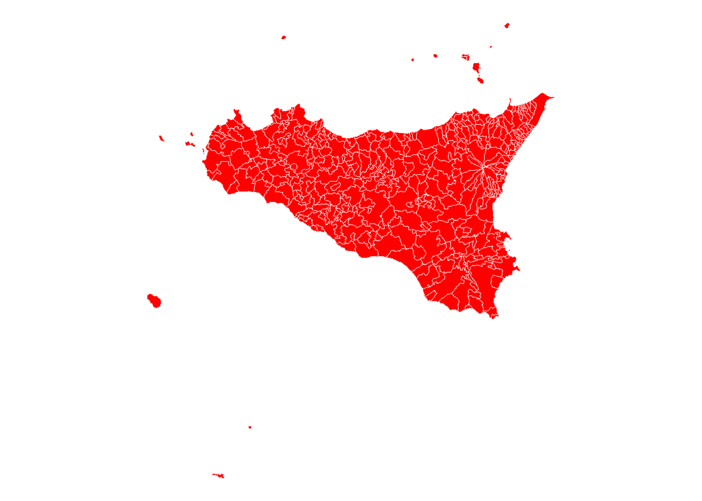

Questa mappa serve come base per successive analisi geografiche.

## Filtraggio degli Alloggi Costieri

Per analizzare specificamente gli alloggi nelle località costiere, creiamo un dataset con località selezionate:

La mappa degli alloggi costieri viene generata come segue:

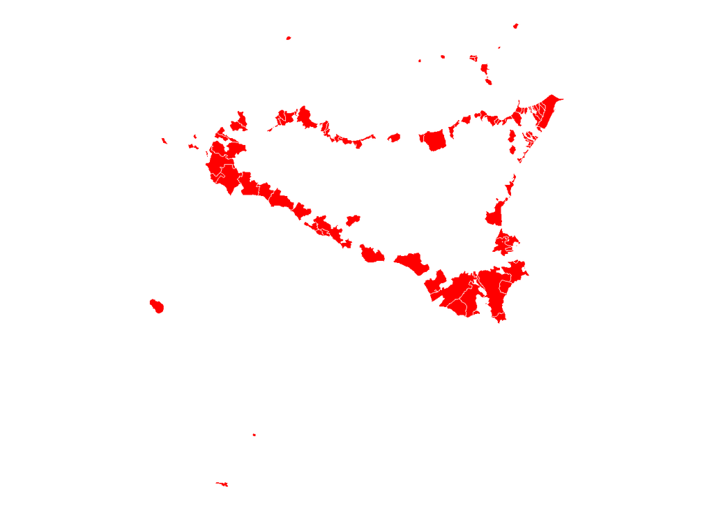

Sulla mappa sono presenti spazi vuoti ma possiamo dire che approssima in maniera soddisfacente i nostri requisiti

## Distribuzione dei Tipi di Alloggio

Un’analisi iniziale riguarda la distribuzione dei tipi di alloggio

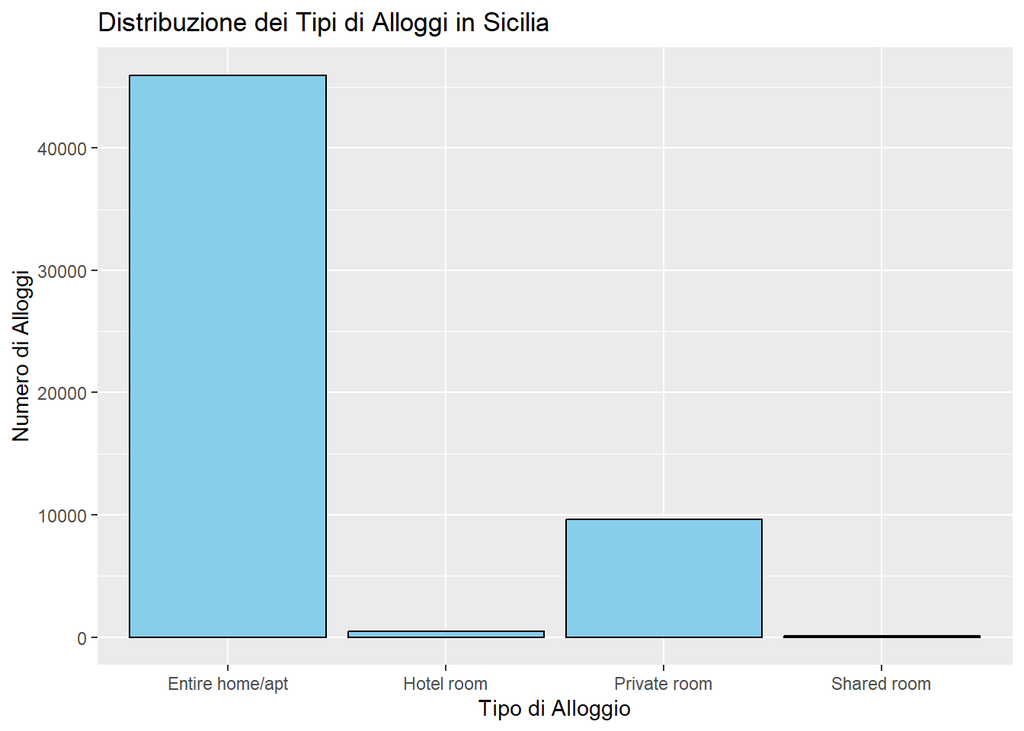

Questo grafico evidenzia la popolarità degli appartamenti indipendenti che quindi avranno un peso maggiore nelle nostre analisi future. Inoltre riflette il mercato tipico di Airbnb, dove gli appartamenti indipendenti sono generalmente preferiti dai viaggiatori per maggiore privacy e flessibilità.

## Analisi dei Prezzi Medi

### Prezzi Medi per Tipo di Alloggio

Calcoliamo e visualizziamo il prezzo medio per ogni tipo di alloggio sia per la Sicilia costiera che per l’intera regione. La nostra ipotesi è che gli alloggi costieri abbiano un prezzo maggiore rispetto alla media generale avendo il mare come “servizio” aggiuntivo.

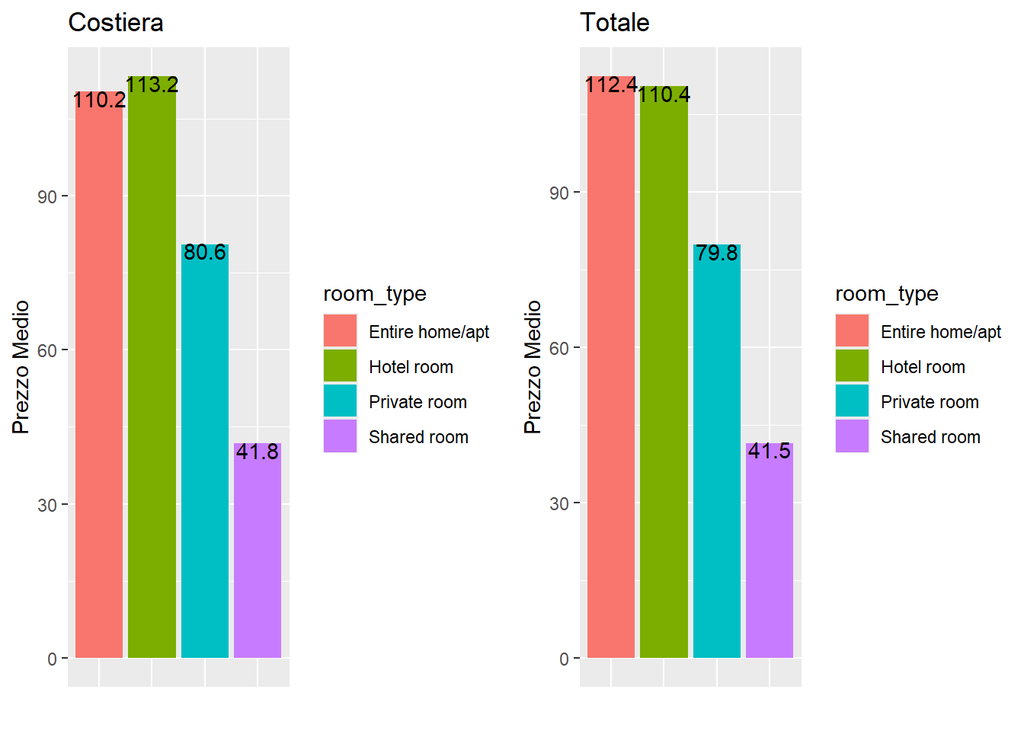

I grafici differiscono di pochi euro, l’esigua differenza nei prezzi medi potrebbe riflettere una forte concorrenza nel mercato costiero, che porta i proprietari a mantenere i prezzi competitivi nonostante l’accesso al mare.

### Heatmap dei Prezzi Medi

adesso visualiziamo la distribuzione geografica dei prezzi medi:

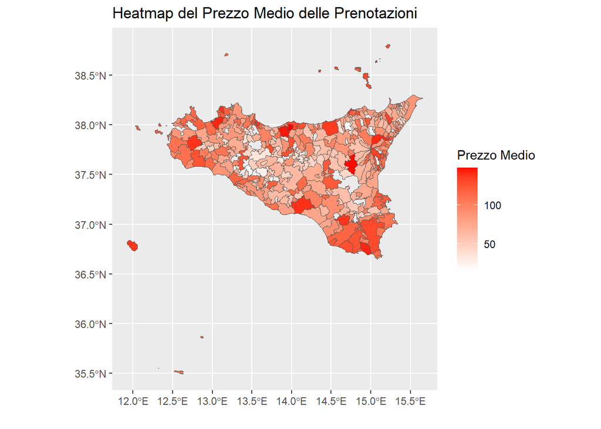

Dalla mappa si evince che i prezzi medi dei comuni sono molto eterogenei e non si riesce a determinare un pattern preciso ma solo alcune zone di accumulo. Ci può venire in aiuto un’ analisi più discreta dei prezzi segmentandoli in classi: “Costoso”,“Medio”,“Economico”

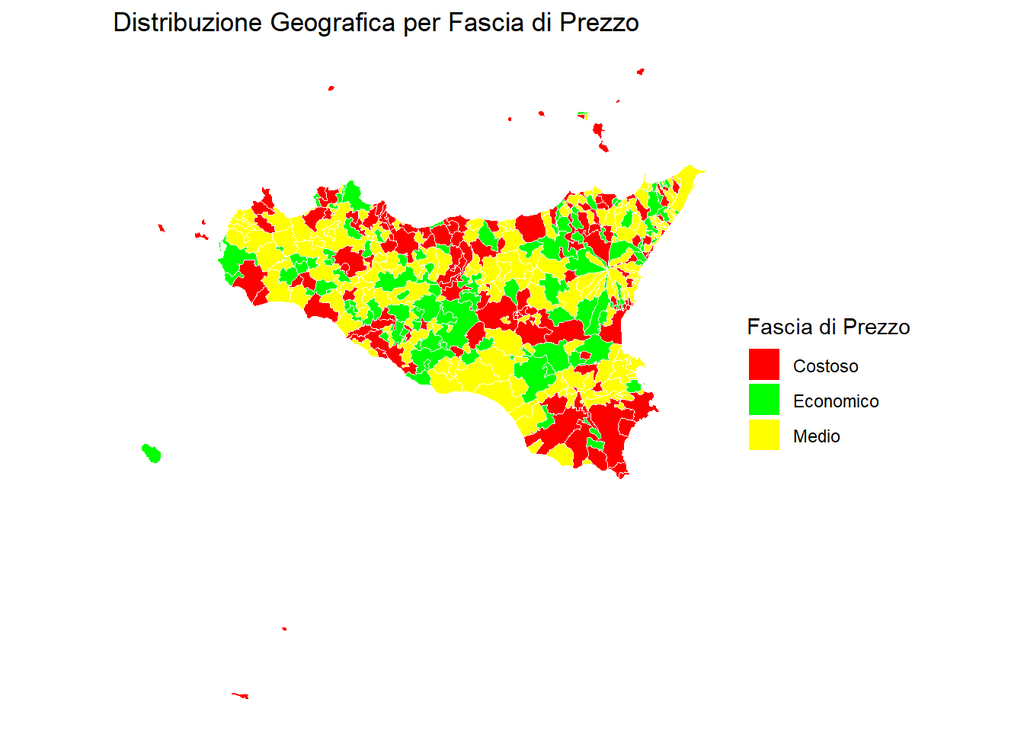

La segmentazione dei prezzi offre un’importante chiave di lettura per gli investitori nell’ immobiliare, aiutandoli ad identificare aree con alto potenziale di ritorno sugli investimenti. Un’altra anlisi utile è vedere come cambia questa mappa nel tempo:

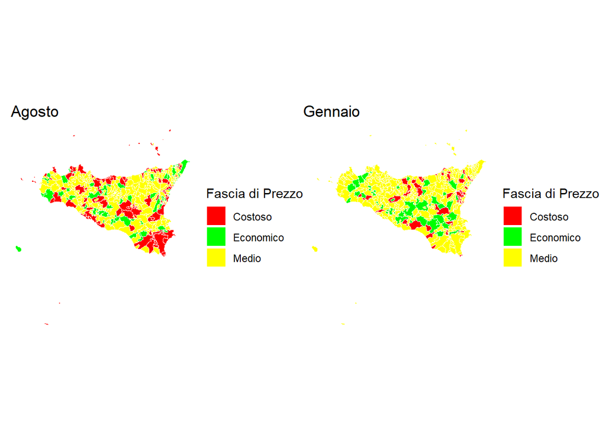

Si nota come in agosto aumentino le zone ad alto costo specialmente lungo le coste concentrate al sud dell’ isola.

## Analisi delle Amenities

Confrontiamo le amenities più frequenti tra gli alloggi costieri e tutti gli alloggi:

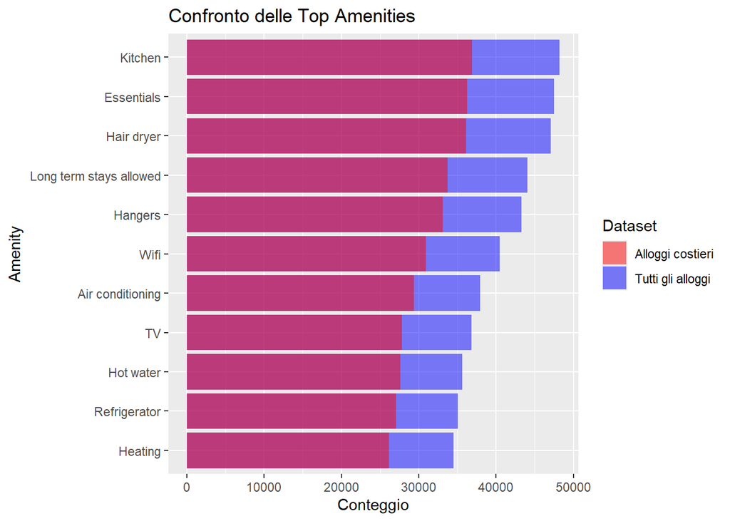

Dall’analisi delle amenities più frequenti, non emergono differenze significative. Le principali amenities, come cucina, Wi-Fi, aria condizionata e riscaldamento, sono presenti in entrambi i gruppi in proporzioni simili, suggerendo che la tipologia di alloggio non influisce significativamente sulle comodità disponibili. Pertanto, non sembra esserci una distinzione marcata tra gli alloggi costieri e quelli non costieri per quanto riguarda le amenities.

## Prezzo Medio in base ai Punteggi delle Recensioni

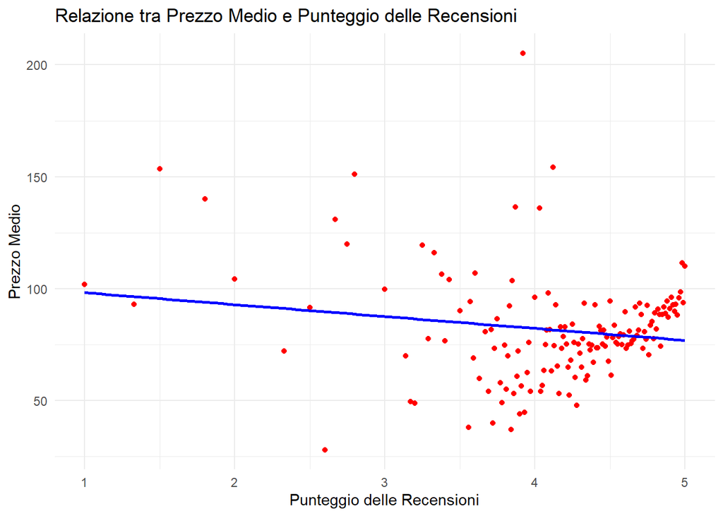

In generale, questa analisi suggerisce che non c’è una forte correlazione tra il punteggio delle recensioni e il prezzo ,oltre che ad una maggiore densità di punteggi nella zona 4-5. Inoltre sono influenzate dalla relazione qualità-prezzo perché i consumatori tendono a bilanciare ciò che ricevono rispetto a ciò che hanno pagato,e questo impatta sulla loro esperienza complessiva e sul punteggio che esprimono.

## Punteggi Medi Geografici

La mappa seguente visualizza i punteggi medi delle recensioni per ogni località:

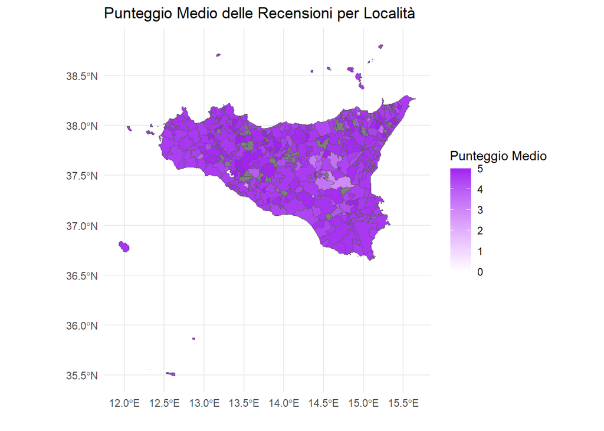

## Analisi Temporale

Essendo il dataset diviso tra regioni costiere e non ci aspettiamo una distribuzione eterogenea tra i due gruppi,dove in quello costiero avremmo una concentrazione maggiore nei mesi caldi, mentre nell’ altro una distribuzione più uniforme.

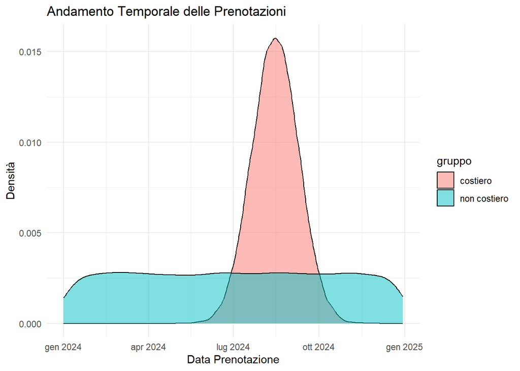

Vediamo adesso se i prezzi medi sono influenzati dalla stagionalità:

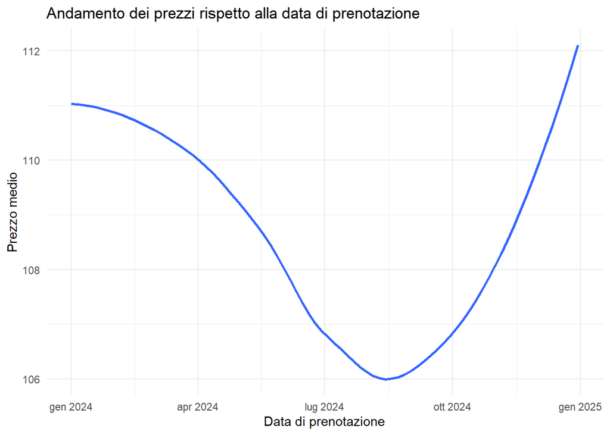

Il risultato di questo grafico scaturisce da questi 2 principali motivi:

1. Una maggiore competitività tra gli host nel periodo estivo.
2. Un maggior quantitativo di prenotazioni nel periodo estivo che quindi contribuisce negativamente nel calcolo del prezzo medio.

## Disponibilità degli host

L ipotesi è che una maggiore disponibilità e rapidità nella possibilità di prenotazione influiscano in modo positivo il numero di prenotazione all host oltre che ad un maggior guadagno.

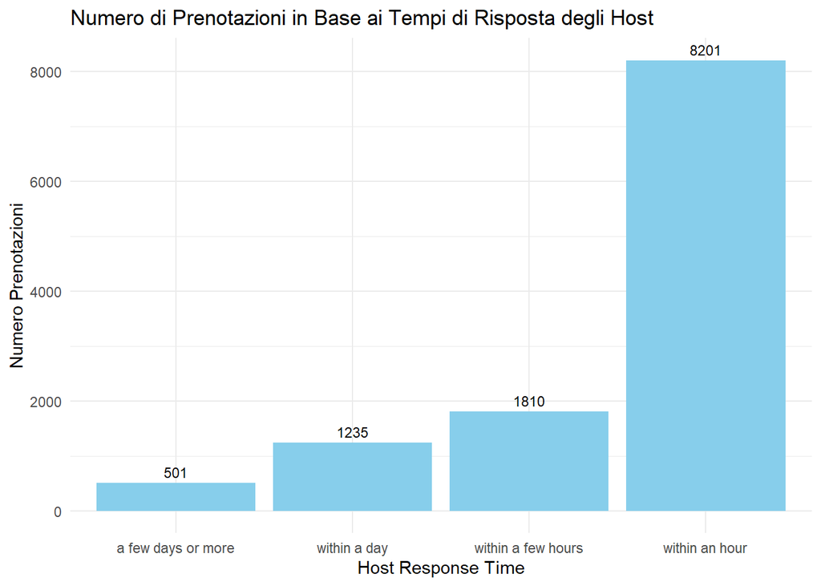

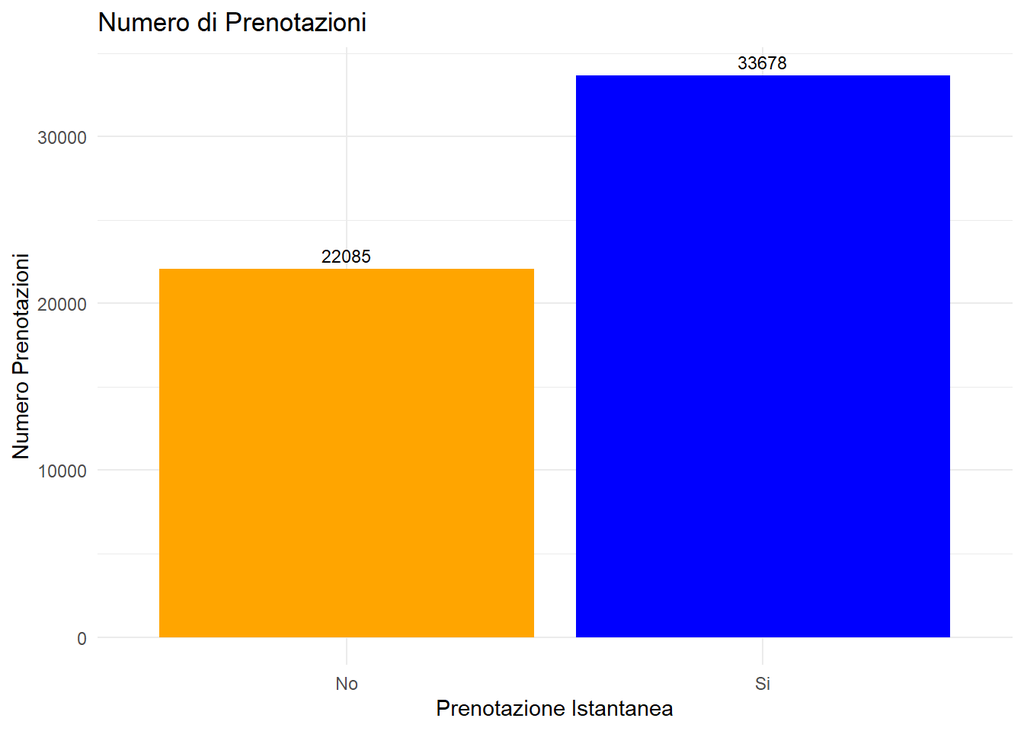

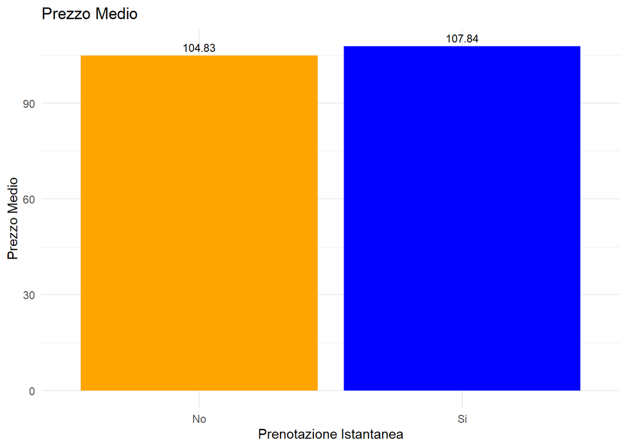

La nostra analisi ha confermato ampiamente l’ipotesi iniziale. Ecco i principali risultati:

Correlazione tra Tempo di Risposta dell’Host e Numero di Prenotazioni: Abbiamo osservato una forte correlazione, le strutture con un tempo di risposta entro un’ora hanno circa 4 volte più prenotazioni rispetto a quelle con tempi di risposta più lunghi. Questo suggerisce che rispondere rapidamente è fondamentale per attrarre più clienti.

Prenotazione Istantanea: Le strutture che abilitano l’opzione di prenotazione istantanea hanno mostrato un aumento del 50% rispetto alle strutture senza questa funzionalità. Questo indica una maggiore domanda e un’interazione più fluida con i clienti grazie all’automazione.

Effetto sui Prezzi: Il prezzo medio mostra delle variazioni minime, con un leggero vantaggio in favore delle strutture con disponibilità immediata. Questo suggerisce che i clienti sono disposti a pagare poco di più per la comodità della prenotazione automatica.

## Credibilità dell’ Host

Analizzando la credibilità dell’host, ci aspettiamo una distribuzione non uniforme tra i gruppi. Foto del profilo e identità verificata sono spesso un indicatore di maggiore affidabilità e sicurezza. Al contrario, l’assenza di queste caratteristiche potrebbe suggerire meno trasparenza e affidabilità. Studieremo come queste caratteristiche influenzano il numero e la distribuzione delle prenotazioni.

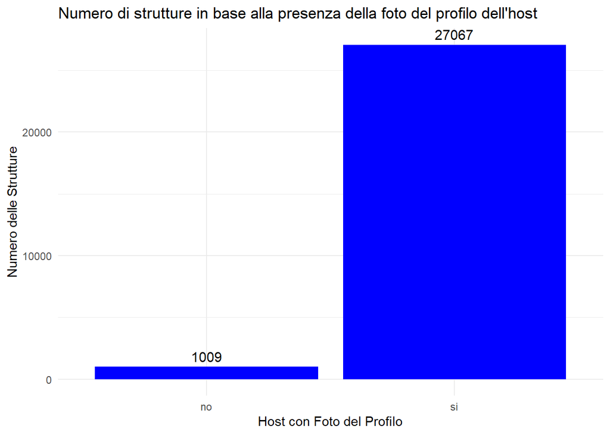

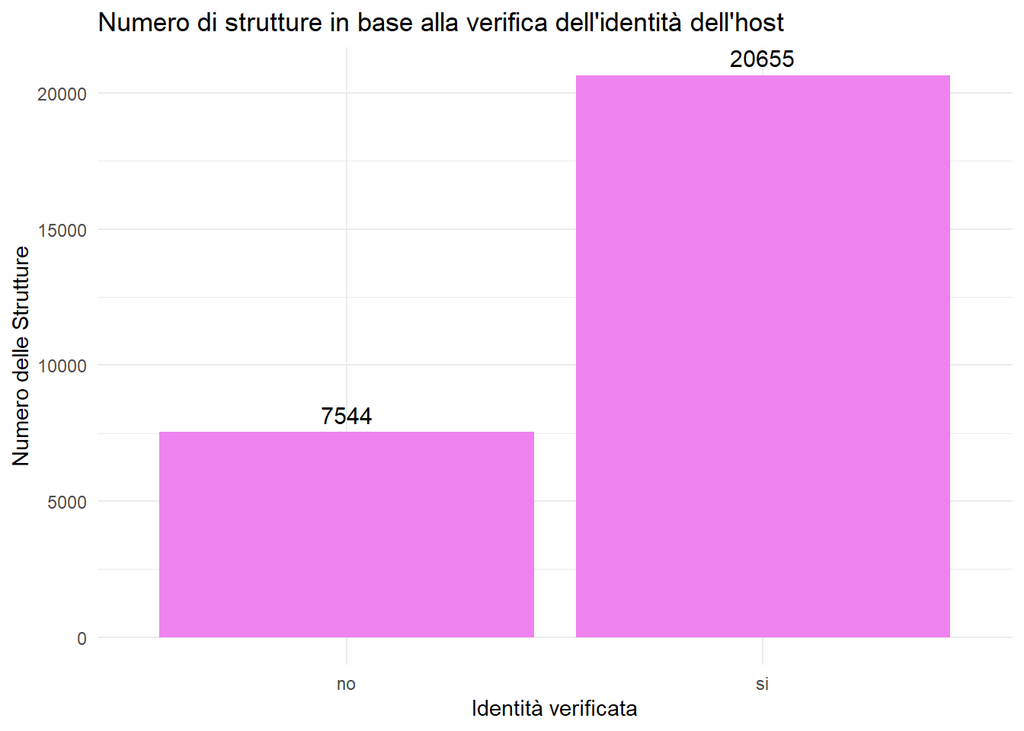

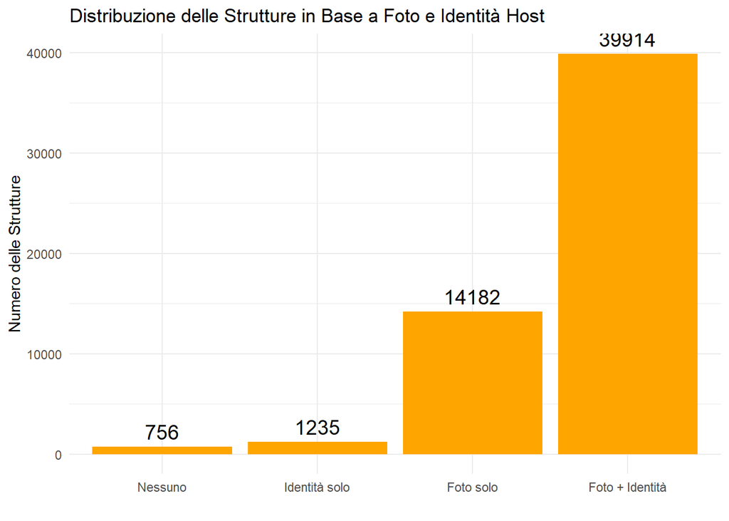

La nostra ipotesi è stata verificata: i dati mostrano chiaramente che gli host con profilo verificato e foto del profilo tendono ad avere una maggiore visibilità e presenza nella piattaforma. Questi elementi di credibilità risultano essere fattori distintivi nella scelta degli utenti, confermando l’importanza della trasparenza nel mercato delle prenotazioni.

## SuperHost

Il Superhost di Airbnb è un riconoscimento assegnato agli host che forniscono esperienze eccezionali agli ospiti. Alcuni requisiti sono la velocità di risposta , la possibilità di cancellazione ed un alto livello di attività sulla piattaforma.

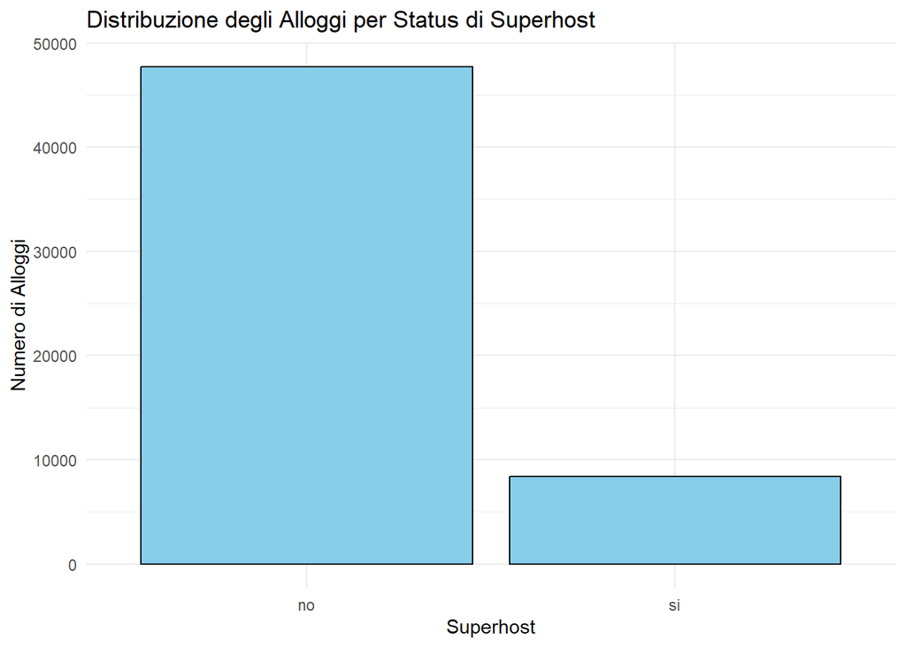

Come ci aspettavamo i superhost non sono tanti, anzi rappresentano solo una minima parte della popolazione.

Vediamo adesso se questo riconoscimento è supportato dalla statistica.

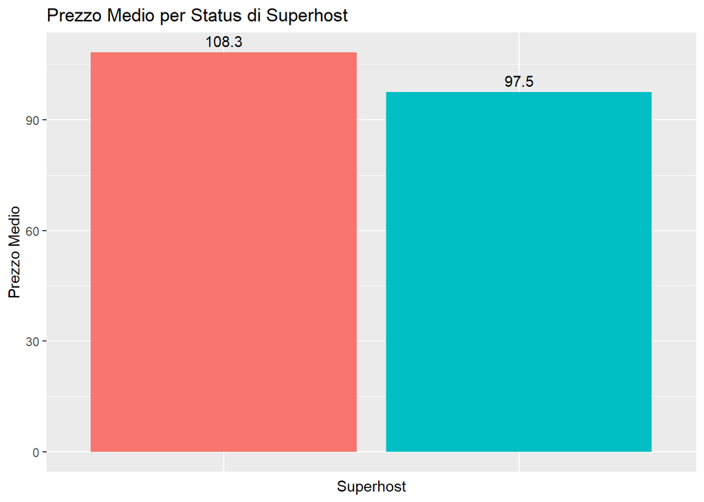

IL fatto di essere Superhost non influenza positivamente le medie dei prezzi, vediamo infatti come addirittura il prezzo medio dei superhost sia più basso.

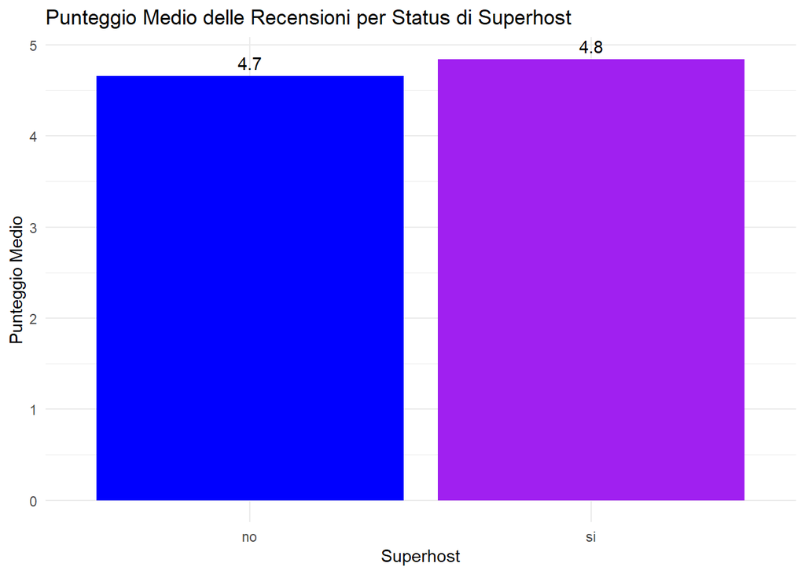

Per quanto riguarda le recensioni, abbiamo un leggero aumento del punteggio ma non in maniera significativa.

Deduciamo, quindi, dal dataset che le persone non sono influenzate dal fatto di soggiornare da un SuperHost o meno.

### Conclusioni

L’analisi dei dati Airbnb in Sicilia ha rivelato dinamiche interessanti e talvolta inaspettate. Nonostante l’attrattività turistica delle località costiere, i prezzi medi degli alloggi in queste zone non si discostano significativamente da quelli nelle aree non costiere. Questo risultato riflette una forte competizione tra gli host, che mantengono i prezzi competitivi nonostante l’accesso al mare possa essere considerato un valore aggiunto.

La stagionalità gioca un ruolo cruciale, soprattutto nelle aree costiere, con una chiara concentrazione di attività nei mesi estivi. Tuttavia, l’aumento della domanda durante l’alta stagione non si traduce necessariamente in un significativo incremento dei prezzi medi, probabilmente per via di un maggiore numero di prenotazioni e di alloggi disponibili.

Le amenities offerte dagli alloggi risultano essere abbastanza uniformi tra le diverse categorie, indicando che i viaggiatori trovano una dotazione standard di servizi indipendentemente dalla posizione geografica. Anche l’analisi delle recensioni suggerisce una bassa correlazione tra punteggio e prezzo, evidenziando che i clienti tendono a valutare principalmente il rapporto qualità-prezzo.

In sintesi, l’analisi evidenzia un mercato dinamico e competitivo, dove la localizzazione e l’efficienza degli host rappresentano i principali fattori di successo. Questi risultati offrono spunti utili per gli investitori e i proprietari che desiderano ottimizzare la loro presenza sulla piattaforma.